# Revenue Forecasting

George C. Sturrock

December 1, 2019

## Introduction

Accurate revenue forecasting is a critical component in the strategic plan of many corporations. Updating and creating meaningful revenue forecasts is a labor intensive, manual effort at many companies. Profit center leaders are asked to make revenue projections for their centers based on their own expertise or methodology. These forecasts are returned to a central planning group where they are reviewed, input, and summarized to make a projection for the company. This process consumes a large swatch of human capital on a periodic basis. Additionally, methods such as copying past year’s numbers or applying a flat period over period growth rate are typically used to produce these numbers. This study investigates statistical, time-series based methods to make revenue projections. In addition to automating the forecasting process, time-series based forecasts may provide superior insights to the methods described above. Several time-series methods are investigated to determine the best model for forecasting revenue over a 12 month horizon.

## Data Exploration and Engineering

The following R libraries are used to support data exploration and the various time series methods used

```r
library(tswge)
library(nnfor)
library(vars)
library(readr)
library(dplyr)
library(forecast)
```

The monthly revenue and opportunities, or leads, are read from CSV format into R.

```r
IEGRevenueMonthly <- read_csv("~/SMU Data Science/TimeSeries/Project/IEGRevenueMonthly.csv",
                              col_types = cols(Invoice_Amount = col_number()))
IEGLeadsMonthly <- read_csv("~/SMU Data Science/TimeSeries/Project/IEGLeadsMonthly.csv")
```

```r
IEGLeads <- IEGLeadsMonthly[3:77,]
IEG <- merge(IEGRevenueMonthly, IEGLeads, by = c("Year", "Month_Nbr"))
head(IEG)
```

```
  Year Month_Nbr Invoice_Amount Leads
1 2013        10       351077.6    25
2 2013        11       266053.2    10
3 2013        12       358464.0    13
4 2013         7       261260.8    25
5 2013         8       274264.9    24
6 2013         9       335891.2    18
```

There is a clear positive correlation between the number of monthly leads and invoiced amounts. This is to be expected as leads directly contribute to billable work which leads to revenue.

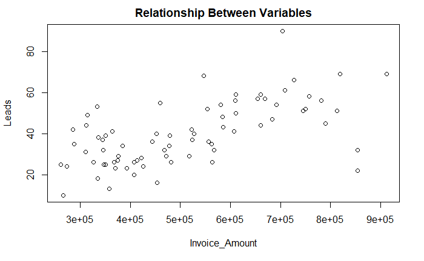

```r
plot(IEG[,3:4], main="Relationship Between Variables")
```

Further investigation of the relationship between invoice amount and leads show the two variables have shared a general upward trajectory over the life of the dataset. A visible lag affect between leads and invoice amount is hard to detect through visual inspection. There appears to be a eight month trend where leads are declining at the end of the dataset. This could result in a similar impact on invoice amount.

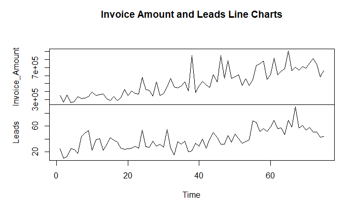

```r
tsIEG <- ts(IEG)
plot(tsIEG[,3:4], main="Invoice Amount and Leads Line Charts")
```

The invoice amount serves as the response variable for this study. The time realizations shows the strong “up and to the right” trend for invoice amounts over the life of the dataset. The realization appears to show a slight wandering pattern around the mean. The sample autocorrelation plot shows a slowly dampening pattern. The periodogram and spectral density plots show a peak around zero with with some wandering around -5 dB. The next highest point is near a frequency of 0.5. There doesn’t appear to be a strong seasonal trend in this dataset.

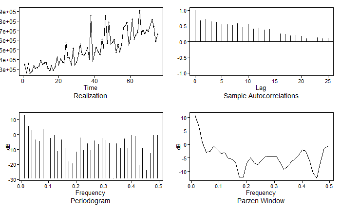

```r
psw <- plotts.sample.wge(IEG$Invoice_Amount, trunc = 50)
```

Closer examination of the output used to produce the spectral density chart shows a the maximum frequency is found at 0.0133. This equates to a period of 75. There are 75 observations in this dataset. This is further proof of a lack of seasonality in the invoice amount data.

```r
i <- which(psw$db==max(psw$db))
max_freq <- psw$freq[i]
period <- 1/psw$freq[i]
cat("max_freq:", max_freq, " period:", period)
```

```
max_freq: 0.01333333  period: 75
```

The expectation is there is a lag effect between leads and invoice amount. The cross-correlation plot shows high points at -2 and 0.

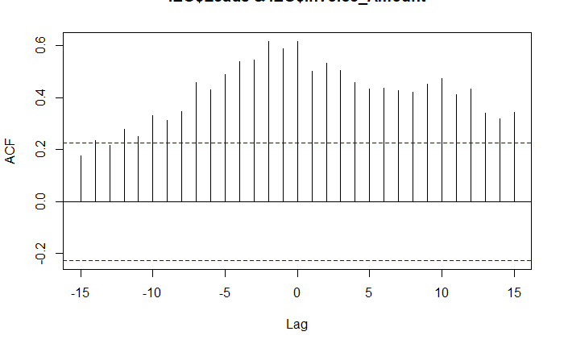

```r
x <- ccf(IEG$Leads, IEG$Invoice_Amount)
```

The maximum ACF is found at observation 14, which is lag -2. However, the similarly high point at 0 is notable as well. For future investigation a “lagLeads” vector is created and attached to the IEG dataframe.

```r
cat("Maximum ACF Lag:", which(x$acf==max(x$acf))) #lag -2
```

```
Maximum ACF Lag: 14
```

```r
lagLeads <- dplyr::lag(IEG$Leads,2)
IEG$lagLeads <- lagLeads
tsIEGlag <- ts(IEG)
```

A final test of the relationship between the leads, lagged leads, and invoice amount can be demonstrated by showing the Pearson R scores to illustrate the strength of the correlation. Both Pearson’s R score are similar. However, the invoice amount and lagged leads produces a slightly higher result.

```r
cat("        Pearson's R - Invoice Amount and Leads:", cor(IEG$Invoice_Amount, IEG$Leads, method = "pearson"), "\n",
    "Pearson's R - Invoice Amount and lagged Leads:", cor(IEG$Invoice_Amount, IEG$lagLeads,use = "pairwise.complete.obs",
                                                          method = "pearson"))
```

```
        Pearson's R - Invoice Amount and Leads: 0.6153088
 Pearson's R - Invoice Amount and lagged Leads: 0.6310544
```

## Time Series Modeling

This section investigates univariate and multi-variate time series models to search for a suitable model for predicting revenue by invoice amount. The horizon for these predictions will be 12 months. The lag of 2 for leads and invoice amounts suggests management must look at least two months ahead to impact forecasting revenue, assuming opportunities (leads) are a primary driver of revenue. While management’s primary operating focus should be on a 2 to 6 month horizon, the 12 month horizon provides a valuable input for strategic decision making. The Average Squared Error (ASE) will be a key tool to judge the quality of the inputs of the different predictions. As this calculation will be repeated frequently, a simple ASE function is introduced below.

```r
func_calc_ASE <- function(actual, pred){
  ASE_out <- mean((actual - pred)^2)
  return(ASE_out)
}
```

### Signal Plus Noise

The univariate model used for this data is a signal plus noise model. As shown above, there appears to be no significant seasonal trend in the data. However, there appears to be a strong upward linear trend in the the revenue (invoice amount) realization with a possible white noise pattern around the linear trend. This basic analysis suggests a linear signal plus noise model may be appropriate.

The linear forecast generated by the signal plus noise model does not track the peaks and valleys of monthly revenue data (as expected). Expectations with management may need to be set when presenting a simple linear trend line to forecast future values. Data education is key to lay the ground work to present this as a viable option. The signal plus noise model can be a powerful tool if the data supports its use.

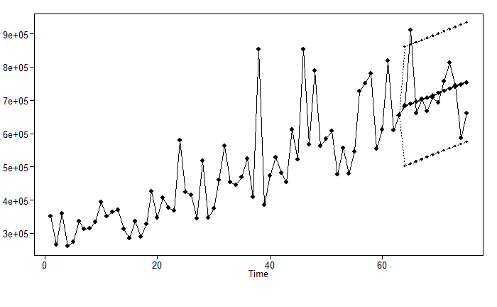

```r
fit.spn <- fore.sigplusnoise.wge(IEG$Invoice_Amount, linear = TRUE, max.p = 5, n.ahead = 12, lastn = TRUE, plot = TRUE)
```

The linear forecast hits several of the actual values almost exactly. The ASE for the signal plus noise model is calculated and displayed below.

```r
ase <- func_calc_ASE(IEG$Invoice_Amount[(length(IEG$Invoice_Amount)-11):length(IEG$Invoice_Amount)], fit.spn$f)
cat("Signal Plus Noise ASE:", ase)
```

```
Signal Plus Noise ASE: 7947044573
```

Additional insight can be gained from the data returned by the signal plus noise model. The slope suggests management should expect revenue to increase by of $6516.99 per month (on average). This information can be used to plan for future headcount, infrastructure, and line of business expansion. More importantly, it is critical to monitory the slope of the forecast over time as well. Since this data tend to return to the mean over time, the changes in forecast slope are likely more important data points than monthly swings in revenue.

```r
fit.spn$b0
```

```
(Intercept)          tl
 265808.600    6516.989
```

To assure the residuals from the fit.spn object resmeble a white noise process, plots and the Ljung-Box test will be used. The residual scatter plot appears to be fairly white.

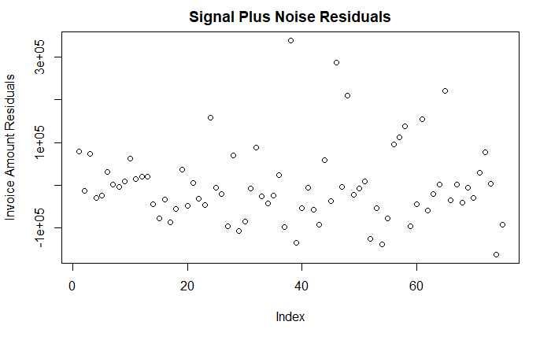

```r
plot(fit.spn$resid[1:length(IEG$Invoice_Amount)], main="Signal Plus Noise Residuals", ylab="Invoice Amount Residuals")
```

The autocorrelation plot shows only one lag barely exeeding the upper limit.

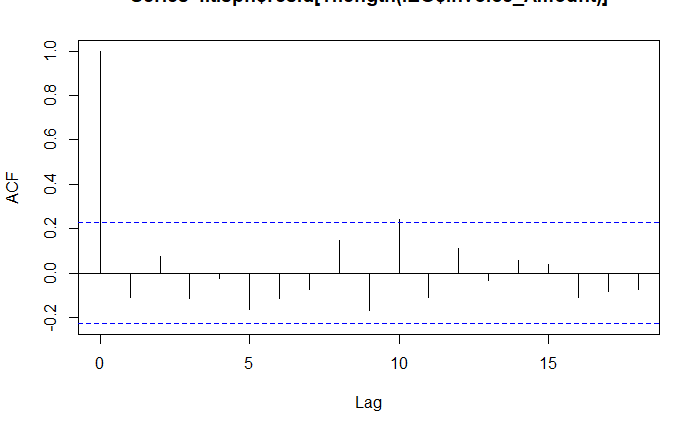

```r
acf(fit.spn$resid[1:length(IEG$Invoice_Amount)])
```

```r
y <- ljung.wge(fit.spn$resid[1:length(IEG$Invoice_Amount)], K=24)
```

```
Obs -0.1096979 0.0759847 -0.1143352 -0.02654594 -0.1623245 -0.1129591 -0.07357202 0.1458633 -0.1710286 0.2412423 -0.1106793 0.1082483 -0.03423305 0.05520335 0.03828945 -0.1125706 -0.08456455 -0.07612231 0.0518522 0.08634334 -0.08295691 0.02307785 0.08936868 -0.0193083
```

```r
z <- ljung.wge(fit.spn$resid[1:length(IEG$Invoice_Amount)], K=48)
```

```
Obs -0.1096979 0.0759847 -0.1143352 -0.02654594 -0.1623245 -0.1129591 -0.07357202 0.1458633 -0.1710286 0.2412423 -0.1106793 0.1082483 -0.03423305 0.05520335 0.03828945 -0.1125706 -0.08456455 -0.07612231 0.0518522 0.08634334 -0.08295691 0.02307785 0.08936868 -0.0193083 0.1188706 -0.07293334 0.0826641…
```

```r
cat("\n", "P-Value at K=24:", y$pval, "\n", "P-Value at K=48:", z$pval)
```

```
 P-Value at K=24: 0.4726113
 P-Value at K=48: 0.62008
```

### VAR

The Vector Auto-Regressive (VAR) model is the allows for multivariate time series modeling. Training and testing dataframes are created to guage the quality of the revenue forecasts produced by the VAR model. VAR models were tested with and without lagged leads. Both models performed well, but the VAR model without lagged leads produced a lower ASE. The VAR modeling begins by using the VARselect function to automatically identify the optimum “p” value. p=1 is selected by all of the “$selection” modes in VARselect. The VAR model is then fit and a forecast is generated.

```r
VARselect(tsIEGlag[1:(nrow(tsIEGlag)-12),c(3,4)], lag.max = 10, type = "both", season=12)
```

```
$selection
AIC(n)  HQ(n)  SC(n) FPE(n)
     1      1      1      1

$criteria
                  1            2            3            4            5            6            7            8            9           10
AIC(n) 2.772994e+01 2.780079e+01 2.784243e+01 2.796960e+01 2.791334e+01 2.796434e+01 2.797178e+01 2.799480e+01 2.790592e+01 2.792570e+01
HQ(n)  2.815881e+01 2.828685e+01 2.838567e+01 2.857003e+01 2.857095e+01 2.867913e+01 2.874376e+01 2.882396e+01 2.879227e+01 2.886922e+01
SC(n)  2.884520e+01 2.906475e+01 2.925509e+01 2.953096e+01 2.962341e+01 2.982310e+01 2.997925e+01 3.015097e+01 3.021079e+01 3.037927e+01
FPE(n) 1.139610e+12 1.241977e+12 1.320561e+12 1.537770e+12 1.500118e+12 1.641371e+12 1.734786e+12 1.882183e+12 1.849342e+12 2.057185e+12
```

```r
fit.var2 <- VAR(tsIEGlag[1:(nrow(tsIEGlag)-12),c(3,4)], p=1, type = "both")
fore.var2 <- predict(fit.var2, n.ahead = 12)
```

The VAR model essentially generates a linear model which is not surprising with a p=1.

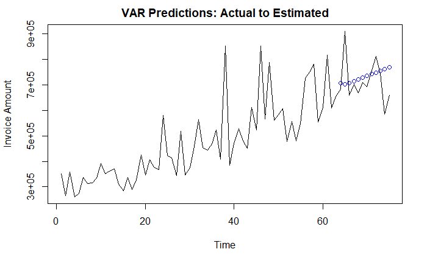

```r
plot(tsIEGlag[,3], main="VAR Predictions: Actual to Estimated", ylab="Invoice Amount", type='l')
lines(seq(64,75,1), fore.var2$fcst$Invoice_Amount[,1], type='p', col = 'blue')
```

The ASE produced by this model is higher than the Signal Plus Noise model.

```r
ase <- func_calc_ASE(tsIEGlag[(nrow(tsIEGlag)-11):nrow(tsIEGlag), 3], fore.var2$fcst$Invoice_Amount[,1])
cat("VAR 2 ASE:", ase)
```

```
VAR 2 ASE: 8308162703
```

The residuals from the fit.var2 object are examined to assure they resemble white noise. The dot plot appears to be reasonably white.

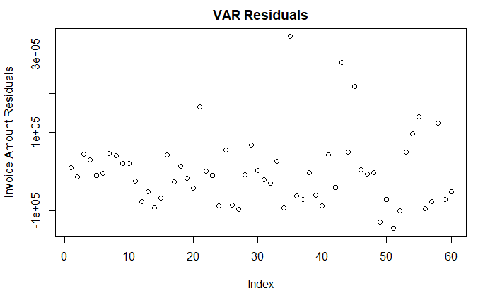

```r
plot(residuals(fit.var2)[,1], main="VAR Residuals", ylab="Invoice Amount Residuals")
```

The ACF plot only have one lag at 10 which exceeds the limit. This could be cause for concern since the value at lag 10 exceeds the limit line by quite a bit.

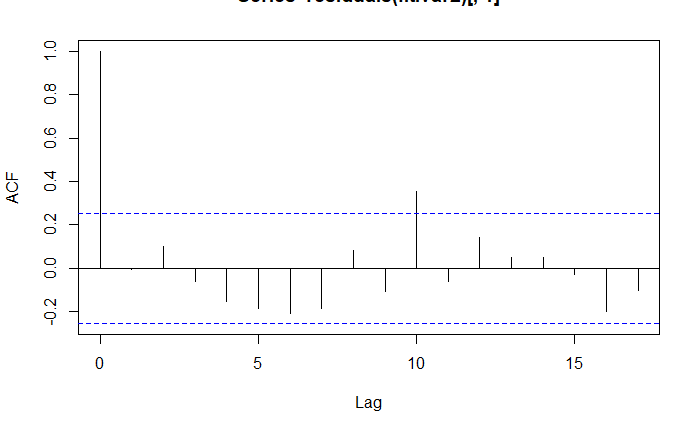

```r
acf(residuals(fit.var2)[,1])
```

```r
y <- ljung.wge(residuals(fit.var2)[,1], K=24)
```

```
Obs -0.004125228 0.1010118 -0.06160398 -0.1530049 -0.187058 -0.210016 -0.1834875 0.08089909 -0.1061253 0.3545889 -0.06317699 0.1406911 0.04905695 0.05006577 -0.02702868 -0.1996139 -0.1021488 -0.039556 -0.02615263 0.1131252 -0.1996991 0.06226262 0.0725141 0.007271907
```

```r
z <- ljung.wge(residuals(fit.var2)[,1], K=48)
```

```
Obs -0.004125228 0.1010118 -0.06160398 -0.1530049 -0.187058 -0.210016 -0.1834875 0.08089909 -0.1061253 0.3545889 -0.06317699 0.1406911 0.04905695 0.05006577 -0.02702868 -0.1996139 -0.1021488 -0.039556 -0.02615263 0.1131252 -0.1996991 0.06226262 0.0725141 0.007271907 0.1098048 0.0315924 0.02209015 -0…
```

```r
cat("\n", "P-Value at K=24:", y$pval, "\n", "P-Value at K=48:", z$pval)
```

```
 P-Value at K=24: 0.09315947
 P-Value at K=48: 0.5701877
```

### Neural Network

Several types of neural networks exists. In this section, a multi-layer perception (MLP) neural network will be trained and tested to evaluate its predictive abilities. To begin, the IEG dataframe is split into train and test dataframes based on a 12 month horizon. A dataframe with extra regressors for leads and time components are created as well. The presence of extra-regressors makes this a multi-variate model.

```r
## Model 4 - 3 extra regressors
iegTrain <- ts(IEG$Invoice_Amount[1:(nrow(IEG)-12)])
iegTest <- ts(IEG$Invoice_Amount[(nrow(IEG)-11):nrow(IEG)])
iegX3 <- data.frame(Year = ts(IEG$Year), ts(IEG$Month_Nbr), ts(IEG$Leads))
```

The MLP neural network is fit using the training dataframe. Thrity networks are trained and used to produce an ensemble forecast. The “hd.auto.type = ‘cv’” is chosen to allow the mlp function to choose the optimal number of nodes and hidden layers for the MLP using five fold cross validation. The dataframe of extra-regressors is input as well. Many variations of an MLP were tested prior to selecting this particular model. The resulting fit plot shows a fairly linear network. There are 8 total inputs (invoice amount, leads, two time components, and four lagged inputs) and one hidden layer in the ensemble nework.

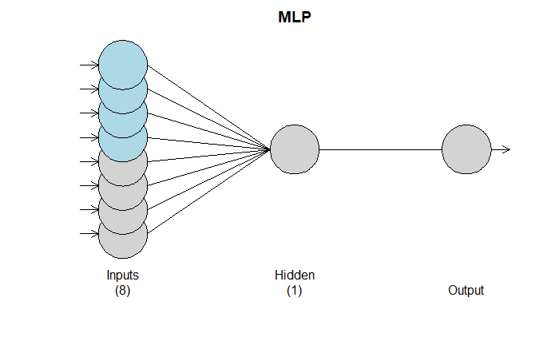

```r
#fit model and calc ASE
set.seed(8)
fit.mlp <- mlp(iegTrain, hd.auto.type = 'cv', reps = 30, xreg = iegX3)
plot(fit.mlp)
```

A forecast is generated using the ‘fit.mlp’ object created above. The forecast shows a fairly compact distribution of the 30 individual networks (grey lines) with the ensemble forecast (blue line) shows the actual forecasted values.

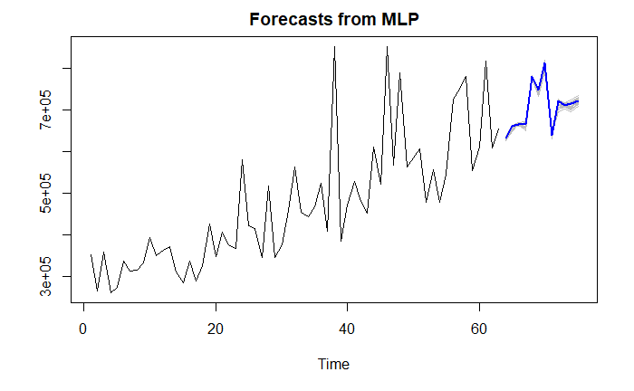

```r
fore.mlp <- forecast(fit.mlp, h=12, xreg = iegX3, level = 95)
plot(fore.mlp)
```

This forecast can be compared to the actual last 12 actual invoice amount observations. The plot focuses an the comparison of the actual (black line) to estimated (blue line) values. Visual examination suggests the model is generally in the neighborhood of the actual values, but it does not seem to match the overall peaks and values of the actual values. The calculated ASE is displayed as well.

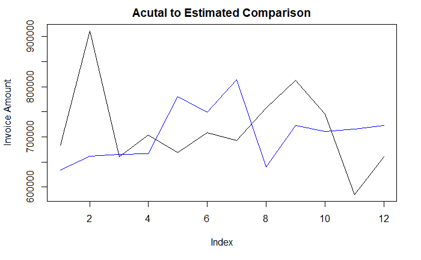

```r
plot(IEG$Invoice_Amount[(nrow(IEG)-11):nrow(IEG)],type = "l", main='Acutal to Estimated Comparison', ylab="Invoice Amount")
lines(seq(1,12),fore.mlp$mean[1:12], col = "blue", type = 'l')
```

```r
ase <- func_calc_ASE((iegTest[1:length(iegTest)]), fore.mlp$mean[1:length(fore.mlp$mean)])
cat("MLP ASE:", ase)
```

```
MLP ASE: 11613752691
```

The plotted residuals from the MLP model appear to resemble white noise.

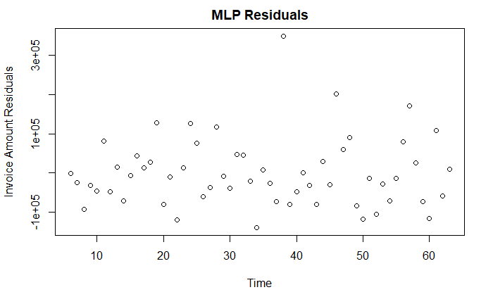

```r
#check residuals
plot(fore.mlp$residuals, type='p', main="MLP Residuals", ylab="Invoice Amount Residuals")
```

The autocorrelations stay within the limits through lag 17.

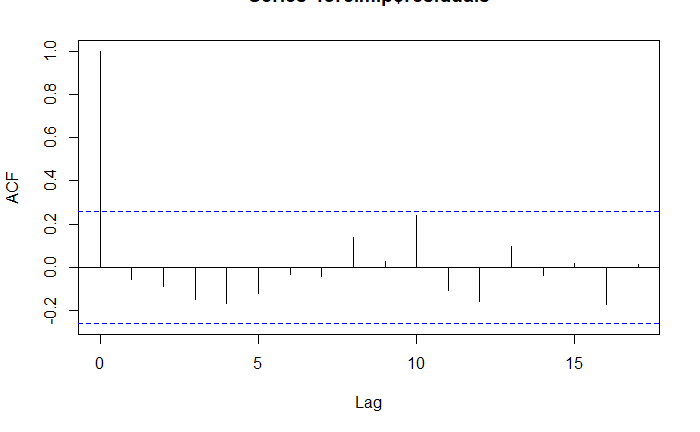

```r
acf(fore.mlp$residuals)
```

The Ljung-Box test is used to verigy the residuals from the MLP time series model resembles white noise. Test with K=24 and K=48 are run. Both fail to reject the null hypothesis with P Values greater than a level of significance of 0.05. Based on the dot plot, ACF plot, and Ljung-Box test results, the residuals from the MLP model appear to be white noise.

```r
y <- ljung.wge(fore.mlp$residuals, K=24)
```

```
Obs -0.05374786 -0.08687043 -0.1467902 -0.1662849 -0.1192888 -0.03045946 -0.04341313 0.1398141 0.02882367 0.2409329 -0.1074392 -0.1584875 0.09760776 -0.03908731 0.01905193 -0.1686831 0.01551907 -0.03649086 0.2308352 0.04861956 -0.07116522 -0.03934816 0.08654569 -0.1998371
```

```r
z <- ljung.wge(fore.mlp$residuals, K=48)
```

```
Obs -0.05374786 -0.08687043 -0.1467902 -0.1662849 -0.1192888 -0.03045946 -0.04341313 0.1398141 0.02882367 0.2409329 -0.1074392 -0.1584875 0.09760776 -0.03908731 0.01905193 -0.1686831 0.01551907 -0.03649086 0.2308352 0.04861956 -0.07116522 -0.03934816 0.08654569 -0.1998371 0.04640547 -0.0721469 0.075…
```

```r
cat("\n", "P-Value at K=24:", y$pval, "\n", "P-Value at K=48:", z$pval)
```

```
 P-Value at K=24: 0.2994036
 P-Value at K=48: 0.8850433
```

### Ensemble Model

Several combinations of the Signal Plus Noise, VAR, and MLP models were created to identify a suitable ensemble model. The various differnt ensemble formulas with their ASE scores are shown below. None of the models produce an ASE score superior to the Signal Plus Noise model. The story told by the different ensemble models is the closer the results mirror the Signal Plus Noise model, the better the result. For completeness, the ensemble model chosen for this study is conceptually borrowed from the PERT estimating formula. The PERT estimating formula is a weighted average technique typically used in project estimation. Optimistic, pessimistic, and most likely time estimates are gathered and fed into the formula shown below:

$\frac{pessimtic + (4*most likely) + optimistic}{6}$

```r
fore.ensemble <- (fit.spn$f + fore.mlp$mean)/2 #Ensemble ASE: 9131942791
fore.ensemble3 <- (fit.spn$f + fore.mlp$mean + fore.var2$fcst$Invoice_Amount[,1])/3 #Ensemble ASE: 8614463855
fore.ensemblePert <- ((fit.spn$f*4) + fore.mlp$mean + fore.var2$fcst$Invoice_Amount[,1])/6 #Ensemble ASE: 8214875775
fore.ensemble4 <- ((fit.spn$f*3) + fore.mlp$mean)/4 #Ensemble ASE: 8377379721
fore.ensemble5 <- ((fit.spn$f*5) + fore.mlp$mean)/6 #Ensemble ASE: 8197909347
fore.ensemble6 <- (fit.spn$f + fore.var2$fcst$Invoice_Amount[,1])/2 #Ensemble ASE: 8072032062
fore.ensemble7 <- ((fit.spn$f*3) + fore.mlp$mean + (fore.var2$fcst$Invoice_Amount[,1]*2))/6
```

While the desired effect of allowing some variability from the MLP model into the mostly linear results of the Signal Plus Noise and VAR models is achieved. However, the variability introduced by the MLP model produces monthly forecasts which run counter to the actual in several instances.

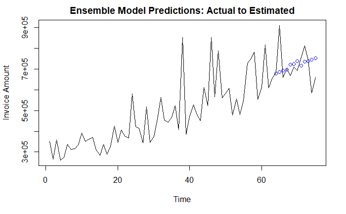

```r
plot(tsIEGlag[,3], main="Ensemble Model Predictions: Actual to Estimated", ylab="Invoice Amount", type='l')
lines(seq(64,75,1), fore.ensemblePert, type='p', col = 'blue')
```

```r
ase <- func_calc_ASE((iegTest[1:length(iegTest)]), fore.ensemble7[1:length(fore.ensemble3)])
cat("Ensemble ASE:", ase)
```

```
Ensemble ASE: 8244191442
```

## Model Selection

[output not shown]

## Forecasting

The Signal Plus Noise forecast for the next 12 months is shown below.

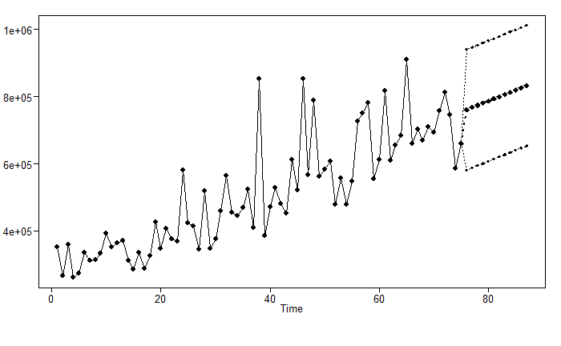

```r
t <- fore.sigplusnoise.wge(IEG$Invoice_Amount, linear = TRUE, max.p = 5, n.ahead = 12, lastn = FALSE, plot = TRUE)
```